# Wavelet screening on methylation

William R.P. Denault et al.

19/02/2020

## Preparing the data

Loading the data and recoding the phenotype from factor to numeric.

```r
load("simulated_data.Rdata")
colon.state[1:4]
```

```
## [1] normal tumor  normal tumor
## Levels: normal tumor
```

```r
pheno <- as.numeric(colon.state)-1
pheno[1:4]
```

```
## [1] 0 1 0 1
```

The data are compound of two more element: * The base pair position of each CpG * The individual CpG level (in M values)

```r
temp.pos[1:10]#the base pair position of each CpG
```

```
##  [1] 212950 212989 213022 213055 213094 213127 213160 213199 213233 213266
```

```r
length(temp.pos)#total number of CpG
```

```
## [1] 75069
```

```r
dim(sim_methy_all)#lines= CpG level, column individual
```

```
## [1] 75069    26
```

```r
sim_methy_all[1:10,]
```

```
##              [,1]       [,2]        [,3]       [,4]         [,5]       [,6]
##  [1,]  0.01789069 -0.5979471 -0.26861179 -0.7450518  0.006154367 -0.2316303
##  [2,] -0.12295093 -0.1793961 -0.72841170 -1.3086674 -0.515000732 -0.8252050
##  [3,] -0.60850539 -1.1254358 -1.43378666 -0.2566904 -1.407540420 -1.5996424
##  [4,] -0.13233239 -0.5206948 -0.33446328 -0.9355251  0.378571786 -0.1911608
##  [5,] -0.52356683 -0.1193659 -1.08203326  0.8466020 -0.301928248 -0.4684455
##  [6,] -0.17583869  0.1366015 -0.08845688  0.2800046 -0.349583008  0.1841946
##  [7,] -0.27027873 -0.5149496 -0.98621691 -0.4734249 -0.622979968 -0.8448085
##  [8,] -0.85012038 -1.2079693 -0.80243886 -1.0941048 -0.059525344 -0.7331130
##  [9,] -0.63962465 -0.5387749  0.11230321 -1.0197601  0.155452984  0.4797858
## [10,] -0.38126215 -0.5939619 -1.74599669 -0.2232314 -1.414829111 -1.2352218
##              [,7]       [,8]        [,9]       [,10]      [,11]        [,12]
##  [1,] -1.01687372  1.6369072  1.29521677  0.09090859 -0.7362546  0.568777789
##  [2,] -1.56503759 -0.6358605 -0.54430514 -0.25168886 -0.6505482 -0.228435296
##  [3,] -1.26149751 -2.1215118 -0.95027779  0.29285588 -1.6455165 -1.072475068
```

[output cut: 40 more lines]

### Defining slice

Here we divide the data into regions that have at least 17 CpGs separated by a maximum distance of 500 bp. This results in a missingness rate of 1.89 %

```r
thresh <- 500
tl <- split(temp.pos , cumsum(c(1, diff(temp.pos) > thresh)  ) ) #Remove case with too long distance

#Level of analysis 4
tl <-  tl[-which(lengths(tl)< 17)]#List of the position of CpG that we will later analyse
sum(lengths(tl))/length( temp.pos)#percent missigness
```

```
## [1] 0.981124
```

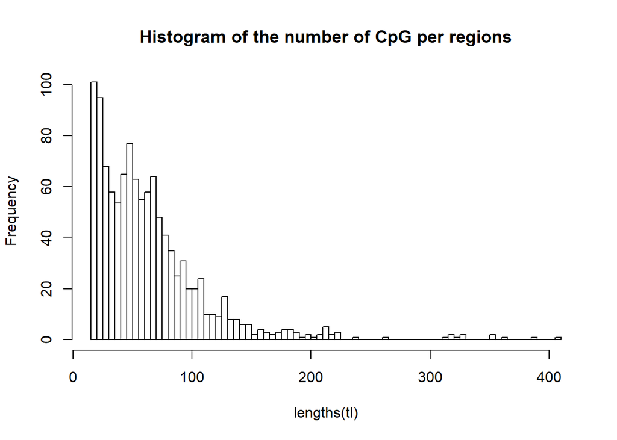

```r
hist( lengths(tl),nclass = 100, main="Histogram of the number of CpG per regions")
```

## Running Wavelet screening region by region

```r
library(WaveletScreening)
tt <- proc.time()
res <- list()
for ( i in 1 :length(tl))
{
  reg_mat <- sim_methy_all[which( temp.pos  %in% tl[[i]]),] #Select CpG in region i
  bp <- temp.pos[which( temp.pos  %in% tl[[i]])]#Correspond to the base position of the CpG of region i
  res[[i]] <- Wavelet_screening( Y=pheno,
                                 loci=reg_mat,
                                 lev_res=4,
                                 coeftype = "c",
                                 bp = bp,
                                 base_shrink = 1/26,
                                 sigma_b =200,
                                 verbose = FALSE
  )


}


proc.time()  -tt #total running time
```

```
##    user  system elapsed
##   53.95    1.84   55.91
```

We concatenate the results of Wavelet screening in one data frame.

```r
res <- do.call( rbind, res)
res[1:10,]
```

```
##              L_h  min_ph_pv     Beta_0_0    Beta_1_1     Beta_1_2     Beta_2_1
##  [1,] -10.892168 0.00000000 -0.102042450  0.04501653 -0.258261702 -0.007768737
##  [2,] -18.604068 0.00000000 -0.065289572 -0.09134897  0.008579152 -0.072190861
##  [3,] -13.846078 0.00000000  0.002647418 -0.12631846 -0.013546850 -0.116194972
##  [4,]  -1.198495 0.56447538 -1.187995204 -0.12056095 -1.066627320 -0.056044266
##  [5,]  -2.143019 0.50878409  0.442588878  0.05376592  1.349828866 -0.044537698
##  [6,] -13.089435 0.00000000  0.021123125  0.17531647  0.042197850  0.158239504
##  [7,] -13.568792 0.00000000  0.014476640 -0.09048563  0.062370918  0.079588710
##  [8,] -13.849895 0.00000000  0.029041037  0.06711068 -0.035738053  0.037775293
##  [9,] -14.853967 0.00057376  0.050233649  0.06462273 -0.060672061  0.013432911
## [10,] -17.021486 0.00000000 -0.033038633 -0.02648544 -0.133385878  0.164956585
##           Beta_2_2    Beta_2_3    Beta_2_4     Beta_3_1     Beta_3_2
##  [1,]  0.088332075 -0.15203469 -0.20503552 -0.092637647 -0.117277337
##  [2,] -0.137122155  0.03608488  0.01026217 -0.023809994 -0.170441860
##  [3,] -0.016480948 -0.09295459 -0.08253614 -0.172936285 -0.071946969
```

[output cut: 106 more lines]

## Simulation of the null distribution

To assess the significance of each region, we simulate the null distribution of the test statistic. Below we display how to simulate this distribution/

```r
set.seed(1)
#Simulation function using the same parameter as used in the Wavelet_screening function
tt <- proc.time()
Sim <- Simu_null_emp(res=res,
                     coeftype="c",
                     lev_res = 4,
                     base_shrink = 1/26,
                     size=100000#Number of simulation required
)
```

```
## [1] "Simulation of test statistics"
## [1] "10000 simulations performed"
## [1] "20000 simulations performed"
## [1] "30000 simulations performed"
## [1] "40000 simulations performed"
## [1] "50000 simulations performed"
## [1] "60000 simulations performed"
## [1] "70000 simulations performed"
## [1] "80000 simulations performed"
## [1] "90000 simulations performed"
## [1] "1e+05 simulations performed"
```

```r
proc.time()  -tt #total running time
```

```
##    user  system elapsed
##   45.67    0.78   46.75
```

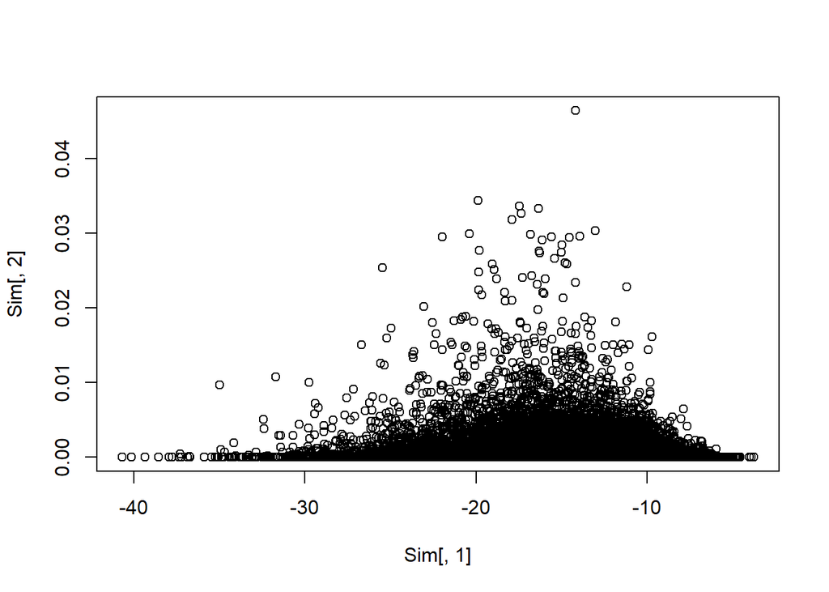

```r
plot( Sim[,1], Sim[,2])
```

## Performing the Box-Cox transform

As explained in the article, the distribution of L<sub>h</sub> might not be Gaussian when analyzing data using low depth. Below, we display how to perform a Box-Cox transform on the simulations of the test statistic under the H<sub>0</sub> .

Here we have an additionnal issue, the observed test statistics contains some positive and negative values. However the Box-Cox transform requires to have only positive values. We therefore shift the distribution and then apply the Box-Cox transform

```r
library(EnvStats)
shifting  <-  max( 0,1.0001*max( Sim[,1],res[,1]))
bc_lambda <-  boxcox(-Sim[,1] + shifting, optimize = TRUE)
Sim[,1]   <-  - ( ( (-Sim[,1] + shifting)^bc_lambda$lambda) -1  )/bc_lambda$lambda
res[,1]   <-  - ( ( (-res[,1] + shifting)^bc_lambda$lambda) -1  )/bc_lambda$lambda
```

## Computing the p-values

When the Box-Cox transform is done, we can then compute the p-value of each region as follow.

```
## [1] "Rought search"
## [1] "Dichotomised search"
```

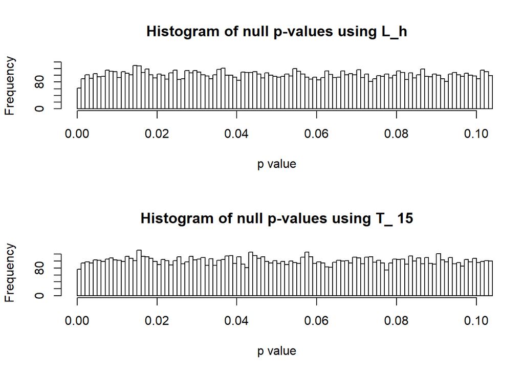

```r
lambda <- Search_lambda(Sim,plot=TRUE)#optimizing the lambda* value
```

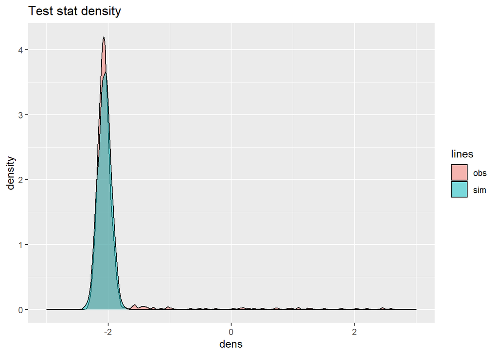

```r
Th <- Sim[,c("L_h")]+lambda*Sim[,c("min_ph_pv")] #Computing the test statistic null distribution
muv <- median(Th,na.rm = TRUE) #estimating the parameter of the null distribution
sdv <- mad(Th,na.rm = TRUE)
####################################
##Test Value of the loci to be tested
####################################
th <-  res[,1]+lambda*res[,2]#Computing the test statistic

##########################
##Plot of two distribution
##########################
dat <- data.frame(dens = c(c(th),c(Th[1:2000]))#To have the same size on the plot
                  , lines = c(rep("obs", length(c(th))), rep( "sim", length(c(Th[1:2000]))) ))

ggplot(dat, aes(x = dens, fill = lines)) +
  geom_density(alpha = 0.5)+
  xlim(c(-3,3))+#Some of the associated regions have test statistics very far from the null; this results in poor visualization if they are not excluded.
  ggtitle("Test stat density")
```

Here we see the null distribution of the test statistic and on the right side of the plot the associated regions.

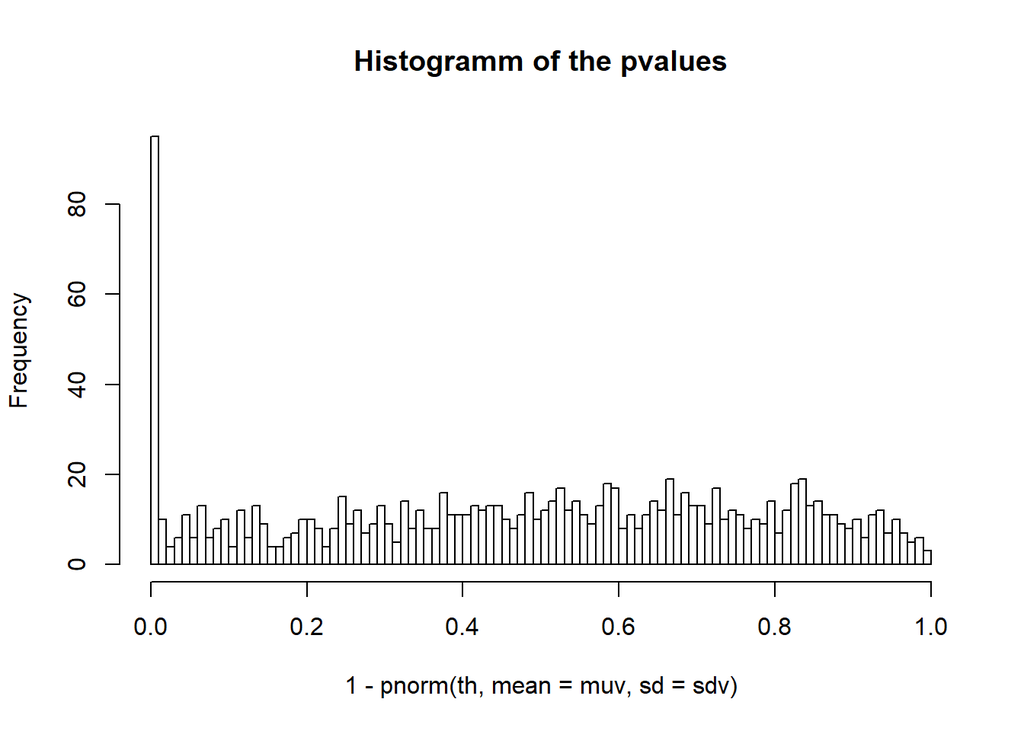

```r
#Computing the p-value
pv <- 1-pnorm(th,mean=muv,sd=sdv)
hist(1-pnorm(th,mean=muv,sd=sdv),nclass=100, main="Histogramm of the pvalues")
```

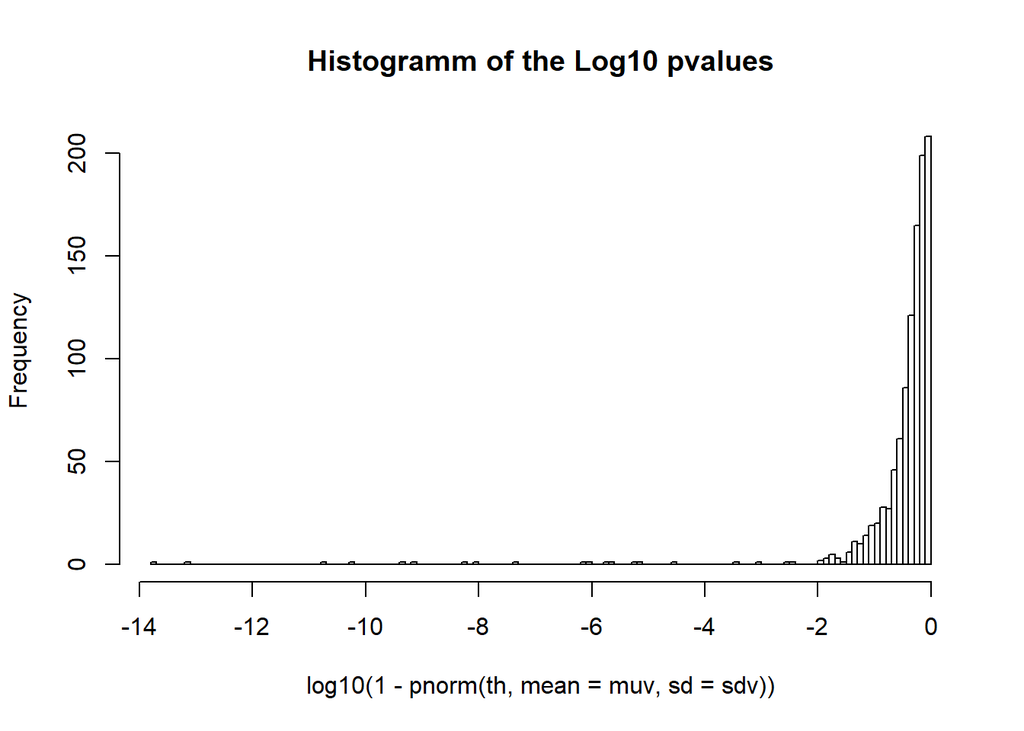

```r
hist(log10(1-pnorm(th,mean=muv,sd=sdv)),nclass=100,main ="Histogramm of the Log10 pvalues")
```

## Loading data from Irizzary et al. 2009 Nature Genetics

The data can be found at https://www.nature.com/articles/ng.298 as supplementary material.

```r
library(readxl)
tt <- read_excel("41588_2009_BFng298_MOESM18_ESM.xls")
sub <- tt[which(tt[,2]=="chr3"),]#Only selecting Chromosome 3
sub <- as.data.frame(sub)
head(sub) #data frame with starting and ending position of each DMR we are trying to detect.
```

```
##    ...1  chr     start       end    delta M colon.tumor colon.normal      fdr
## 1 44705 chr3 193607217 193607552 -0.9357281   0.8858763    1.8981316 0.00e+00
## 2 45816 chr3  82629728  82630444 -0.8377335   0.9777084    1.7687336 0.00e+00
## 3 43646 chr3 129687777 129688211  0.7653712   1.0458169    0.2482736 1.99e-09
## 4 44692 chr3 191521264 191521946 -0.7363103   0.3052087    0.9414630 2.29e-09
## 5 44954 chr3  28591265  28591843  0.6876208   0.8209596    0.1174106 6.39e-08
## 6 43642 chr3 129686645 129687266  0.6589586   1.6160071    0.9675025 3.87e-07
##              state   name   annotation   region distance island distToIsla
## 1 Less methylation  FGF12    NM_021032   inside     1153    Far        960
## 2 Less methylation   GBE1    NM_000158 upstream   736294  Shore     309227
## 3 Some methylation  GATA2    NM_032638   inside     6506  Shore          0
## 4   No methylation  CLDN1    NM_021101   inside      962    Far        562
## 5 Some methylation ZCWPW2 NM_001040432 upstream    49632  Shore          0
## 6 More methylation  GATA2    NM_032638   inside     7451  Shore        916
```

```r
lstemp <- list() #

for (i in 1: dim(sub)[1])
{

  lstemp[[i]] <- temp.pos[ which( (sub$start[i]-1)  < temp.pos & temp.pos < (sub$end[i] +1 ))]

}

sum( lengths(lstemp)) # number of CpG to detect
```

```
## [1] 1901
```

```r
pos_to_detect <-  do.call( c,lstemp)#List of the CpG to detect
```

## Performing a slicing

Ensure the same slicing as before.

```r
thresh <- 500

tl <- split(temp.pos , cumsum(c(1, diff(temp.pos) > thresh)  ) ) #Remove case with too long distance
tl <-  tl[-which(lengths(tl) <17)]#Keep only long enough sequence of CPG

pos_to_detect <- pos_to_detect [which(pos_to_detect %in% do.call( c , tl))] #filtering out the CpG remove when slicing
```

## Power

```r
#N° of CpG per regions
n_CpG_per_region <- list()

for ( i in 1:length(tl))
{
  n_CpG_per_region[[i]] <- pos_to_detect[which(pos_to_detect %in% tl[[i]])]

}


nCpG_reg <- lengths(n_CpG_per_region)
indx_to_detect <- which( nCpG_reg >0)#List of the regions to detect
indx_to_detect
```

```
##  [1]    4    5   14   18   21   56   58   80  100  120  130  134  139  140  143
## [16]  157  168  189  190  221  232  249  327  337  375  413  416  417  448  479
## [31]  508  520  521  527  587  610  614  642  647  670  676  677  689  725  731
## [46]  741  748  760  771  774  775  777  778  795  801  803  804  806  814  817
## [61]  821  822  832  849  858  859  878  879  900  914  915  935  939  941  947
## [76]  977  995  997 1007 1008 1014 1019 1020 1021 1022 1024 1025 1045 1066
```

Regions detected

```r
type <- c("pv", "pv", "fdr", "fdr")
threshold <- c("e-5", "e-6", "5%", "1%")
detected_reg <- c()
tru_reg <- c()
#Regions detected

#When using p-values 10^-5
indx_WS <-  which(pv < 10^(-5))
detected_reg <- c( detected_reg ,length(indx_WS))
tru_reg <- c( tru_reg , length(which(indx_WS %in% indx_to_detect) ) )

#When using p-values 10^-6
indx_WS <-  which(pv < 10^(-6))
detected_reg <- c( detected_reg ,length(indx_WS))
tru_reg <- c( tru_reg , length(which(indx_WS %in% indx_to_detect) ) )
fdr_regions <- p.adjust(pv, method ="BH")

#When using FDR at 5%
indx_WS <-  which(fdr_regions  <0.05)
detected_reg <- c( detected_reg ,length(indx_WS))
tru_reg <- c( tru_reg , length(which(indx_WS %in% indx_to_detect) ) )

#When using FDR at 1%
indx_WS <-  which(fdr_regions  <0.01)
detected_reg <- c( detected_reg ,length(indx_WS))
tru_reg <- c( tru_reg , length(which(indx_WS %in% indx_to_detect) ) )

#Summary
df_out <- data.frame(type=type, threshold = threshold, nb_detected_region= detected_reg, nb_true_regions= tru_reg )
```

```r
df_out
```

```
##   type threshold nb_detected_region nb_true_regions
## 1   pv       e-5                 90              88
## 2   pv       e-6                 86              84
## 3  fdr        5%                 95              89
## 4  fdr        1%                 92              89
```

df_out summaries the number of regions detected using different criteria and the number of truly associated regions.